# A new look on the genotype-by-environment interaction: enviromics and probabilistic models

8th International Meeting on Plant Breeding

Authors

Affiliations

[Kaio Olimpio G. Dias](https://scholar.google.com.br/citations?user=KS9I5bQAAAAJ&hl=pt-BR&oi=ao)

[Departamento de Biologia Geral, Universidade Federal de Viçosa](https://dbg.ufv.br/)

[Institute of computational and artifical intelligence (IDATA)](https://idata.ufv.br/)

[Saulo F. S. Chaves](https://scholar.google.com.br/citations?user=Rt_v_ooAAAAJ&hl=pt-BR)

[Departamento de Biologia Geral, Universidade Federal de Viçosa](https://dbg.ufv.br/)

[Institute of computational and artifical intelligence (IDATA)](https://idata.ufv.br/)

```r
library(tidyverse)
library(sommer)
library(ggrepel)
library(ggpubr)
```

# 1 Introduction

In this tutorial, we show a detailed guide on how to fit reaction norm models accounting for both genomics and enviromics information. This method was first proposed by Jarquin et al. (2014), and was latter expanded and used by several research groups (Campos et al., 2020; Costa-Neto et al., 2021; Toda et al., 2024). This was one of the first initiatives for integrating genomics and enviromics in plant breeding. It is worth mentioning other innovative works on enviromics that can be easily expanded to consider genomic data, like the ones of Fernandes et al. (2024), using machine learning; Araújo et al. (2024), who used GIS data and factor analytic mixed models; and Resende et al. (2024), who propose a new manage for the environmental features before using the reaction norm models.

# 2 Dataset

The data we will use as an example belongs to the “Genomes to Fields” (G2F) initiative . Here is how G2F is described in their homepage:

“Building on prior public funding of plant genome research and operating at a scale necessary to maintain U.S. competitiveness, this Initiative aims to create an interdisciplinary framework for understanding and managing crop performance. Genomes to Fields will not create physical infrastructure but will instead develop a living infrastructure of researchers from many disciplines and a network of field phenotyping sites. The Initiative will generate a large, multi-state, multi-year publicly available dataset of corn phenotype data that will enable researchers to identify connections between variation in heredity material and the environment and the resulting phenotypes (i.e., crop performance). A resource of this type has never before been available to public-sector researchers. A critical part of the Genomes to Fields Initiative is fostering interdisciplinary research collaborations among crop scientists and engineers and computational scientists. The engineers will develop new technologies (e.g., robots and sensors) that will make informative high-throughput phenotyping possible. The computational scientists will develop new computational approaches to analyze the resulting very large (big data) datasets of phenotypes and environmental data and thereby facilitate an understanding of gene function and to address fundamental problems of agricultural productivity. The Initiative’s interdisciplinary network of scientists and datasets will provide an excellent training platform for students studying agriculture, genetics and engineering.”

Find more information on the initiative [here](https://www.genomes2fields.org/home/), and other publicy available dataset (phenotypic, genotypic and enviroment) [here](https://www.genomes2fields.org/resources/)

```r
dat = read.csv(file = 'data/PHENO.csv')
head(dat)
```

```
   year_loc year location               genotype                    source rep
1 2014-MNH1 2014     MNH1 PHN11_LH145_0002/CG102         13WJWE:CG102:1227   2
2 2014-IAH1 2014     IAH1            M0014/LH198         13WJWE:LH198:3022   2
3 2014-IAH1 2014     IAH1            PHB47/LH195 WE13-195ISO-108-X-POL-195   1
4 2014-IAH1 2014     IAH1            M0118/LH198         13WJWE:LH198:3124   2
5 2014-IAH1 2014     IAH1            CG108/CGR03                 GTF-01:43   2
6 2014-IAH1 2014     IAH1            CG119/CG108                 GTF-01:55   2
  block plot seed_number date_plant date_harvest date_anthesis date_silking
1     1   42          40 2014-05-16   2014-10-16    2014-07-20   2014-07-23
2     1    9          72 2014-05-17   2014-10-21    2014-07-21   2014-07-24
3     2   25          72 2014-05-17   2014-10-20    2014-07-26   2014-07-26
4    12  426          72 2014-05-17   2014-10-21    2014-07-23   2014-07-25
5    11  406          72 2014-05-17   2014-10-21    2014-07-12   2014-07-14
6    11  386          72 2014-05-17   2014-10-21    2014-07-11   2014-07-11
  plants_stand grain_moisture     yield anthesis silking ASI anthesis_GDD
```

[output cut: 20 more lines]

The loaded dataset has 4372 genotypes, tested across 136 trials (henceforth called “environments”) through 8 years. For didactic purposes, we will subset two years. Furthermore, we will select only environments that were implemented in randomized complete blocks design.

```r
dat = droplevels(dat[which(dat$year %in% c(2016,2017)),])
dat = droplevels(dat[which(dat$year_loc %in%
                             names(which(
                               apply(as.matrix(table(
                                 dat$year_loc, dat$rep
                               )), 1, function(x)
                                 length(which(x == 0))) != 3
                             ))),])
```

Now, our dataset has 567 genotypes, tested across 33 trials. Let’s check the connectivity between environments Figure 1.

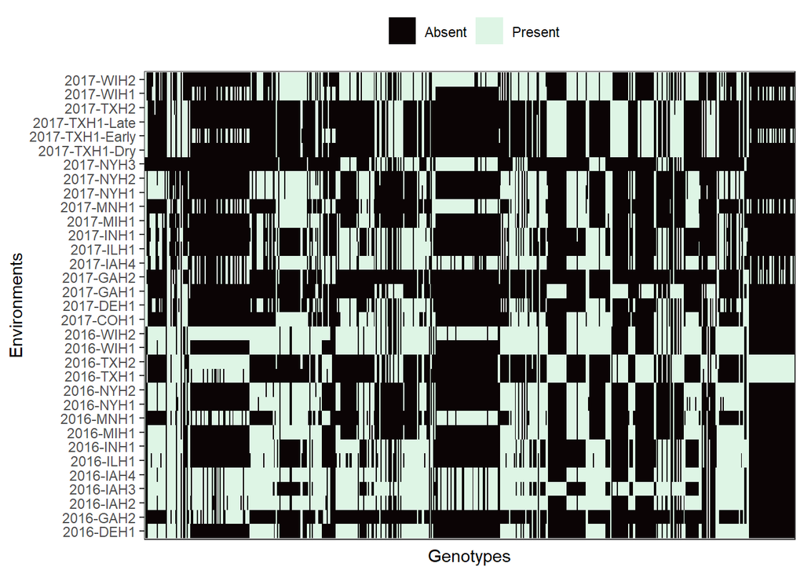

Figure 1: Heatmap depicting the connectivity between environments. Black cells indicate that the genotype in the x-axis is abscent of the environment in the y-axis. Blue cells indicate presence

```r
connec = as.data.frame(table(dat$genotype, dat$year_loc))
connec$Freq = ifelse(connec$Freq != 0, "Present", "Absent")
connec |> ggplot(aes(x = Var1, y = Var2, fill = factor(Freq))) +
  geom_tile() +
  theme_bw() + theme(legend.position = 'top', axis.text.x = element_blank(),
                     axis.ticks.x = element_blank()) +
  scale_fill_viridis_d(option = 'mako') +
  labs(x = "Genotypes", y = "Environments", fill = '')
```

The connectivity is not complete. While this isn’t a major issue, it’s important to remember that better-connected trials lead to more precise estimates of parameters and means.

# 3 Single-environment models

Usually, the reaction norm model is fitted using adjusted means (BLUEs). Thus, we have to perform a two-stage analysis, using the genotypic effect as fixed in first step, in single-environment models. These models are be described as follows:

$$\mathbf{y} = \mathbf{1} \mu + \mathbf{X}_1 \mathbf{b} + \mathbf{X}_2 \mathbf{g} + \boldsymbol{\varepsilon}$$

where $\mathbf{y}$ is the vector of phenotyes, $\mu$ is the model’s intercept, $\mathbf{b}$ is the vector of fixed block effects, $\mathbf{g}$ is the vector of fixed genotypic effects, and $\boldsymbol{\varepsilon}$ is the vector of random residual effects $\left[ \boldsymbol{\varepsilon} \sim \mathcal{N} \left( \mathbf{0}, \sigma^2_\varepsilon \mathbf{I} \right) \right]$. $\mathbf{1}$ is a vector of ones, and $\mathbf{X}_1$ and $\mathbf{X}_2$ are incidence matrices of $\mathbf{b}$ and $\mathbf{g}$, respectively.

We will also fit a version of the model above considering the genotypic effect as random $\left[ \mathbf{g} \sim \mathcal{N} \left( \mathbf{0}, \sigma^2_g \mathbf{I} \right) \right]$, so we can check the effect’s significance via likelihood ratio test (LRT), and estimate the broad-sense heritability. These metrics are calculated as follows:

$$LRT = -2(logL_r - logL_c)$$

where $logL_r$ and $logL_c$ is the logarithm of the residual maximum likelihood function of the reduced and complete models, respectively. The LR statistics is asymptotically distributed as a $\chi^2 \sim 1$ degree of freedom

$$H^2 = \frac{\sigma^2_g}{\sigma^2_g + \frac{\sigma^2_\varepsilon}{r}}$$

where $r$ is the number of blocks.

We also computed the coefficient of experimental variation as:

$$CV = \frac{\sqrt{\sigma^2_\varepsilon}}{\mu}$$

```r
dat.split = split(x = dat, f = dat$year_loc)

indiv.results = lapply(dat.split, function(x){

  message("====> Environment: ", unique(x$year_loc))

  x = transform(x, genotype = as.factor(genotype), block = as.factor(block))

  mfix = mmer(fixed = yield ~ block + genotype,
              rcov = ~ units,
              data = x)
  blue = coef(mfix)
  mu = blue[1, 3]
  blue = x |> reframe(yield = mean(yield), .by = c("genotype")) |>
    left_join(
      blue[grepl("genotype", blue$Effect), ] |>
        mutate_at("Effect", str_replace, "genotype", '') |>
        rename(genotype = Effect),
      by = 'genotype'
    ) |>
    mutate(Estimate = ifelse(is.na(Estimate), 0, Estimate) + mu,
           env = unique(x$year_loc)) |>
    dplyr::select(-Trait, -yield) |>
    rename(blue = Estimate) |> relocate(env, .before = genotype)


  mrand = mmer(fixed = yield ~ block,
                 random = ~ genotype,
               rcov = ~units,
                 data = x)
  lrtest = anova(mrand, mmer(fixed = yield ~ block, data = x))
  vc = summary(mrand)$varcomp

  list(
    params = data.frame(
      s2g = vc[1,1],
      s2e = vc[2,1],
      H2 = vc[1,1]/(vc[1,1] + (vc[2,1]/nlevels(x$block))),
      CV = sqrt(vc[2,1])/mean(x$yield, na.rm = TRUE),
      mu = mean(x$yield, na.rm = TRUE),
      lrt = as.numeric(strsplit(lrtest$PrChisq[2], split = ' ')[[1]][1])
    ),
    blues = blue
  )
})
params = do.call(rbind, lapply(indiv.results, function(x) x$params)) |>
  rownames_to_column("env")
blues = do.call(rbind, lapply(indiv.results, function(x) x$blues)) |>
  filter(env %in% params[which(!params$lrt > 0.05), 'env'])
```

## 3.1 Graphical overview

Some plots can help us understand the dataset. For instance, Figure 2 shows that some environments seem to be more suitable for grain yield, a first evidence of genotype-by-environment interaction (GEI). Figure 3 is the final evidence we needed: genotypes have a different performance according to the environment they are tested. This is the core idea of GEI.

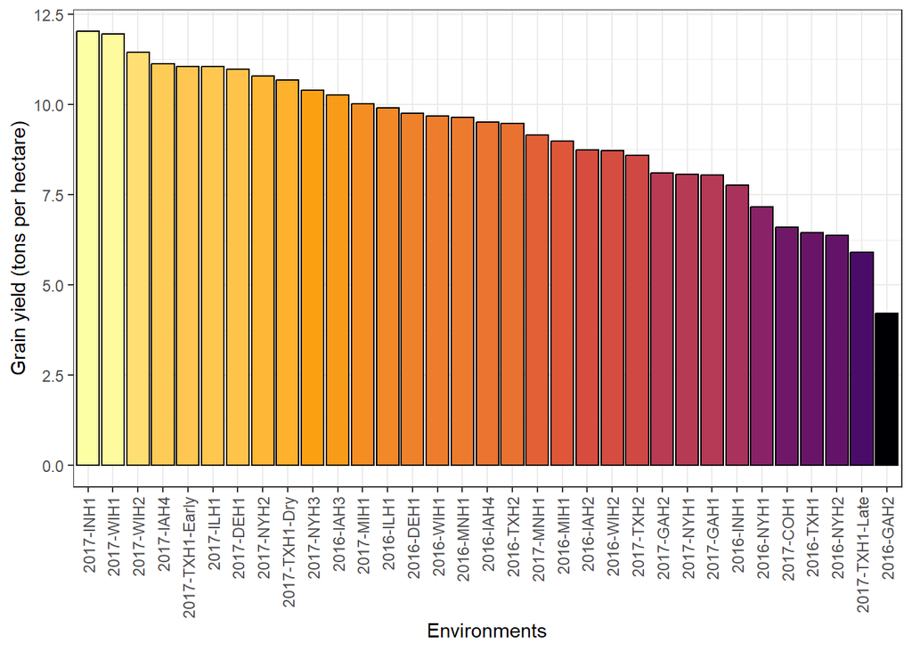

Figure 2: Mean grain yield (y-axis) per environment (x-axis). The environments are in sorted in decreasing order

```r
params |> ggplot(aes(x = reorder(env, -mu), y = mu)) +
  geom_col(colour = 'black', aes(fill = mu)) + theme_bw() +
  theme(legend.position = 'none',
        axis.text.x = element_text(angle = 90, vjust = 0.5, hjust = 1)) +
  labs(x = "Environments", y = "Grain yield (tons per hectare)") +
  scale_fill_viridis_c(option = 'inferno')
```

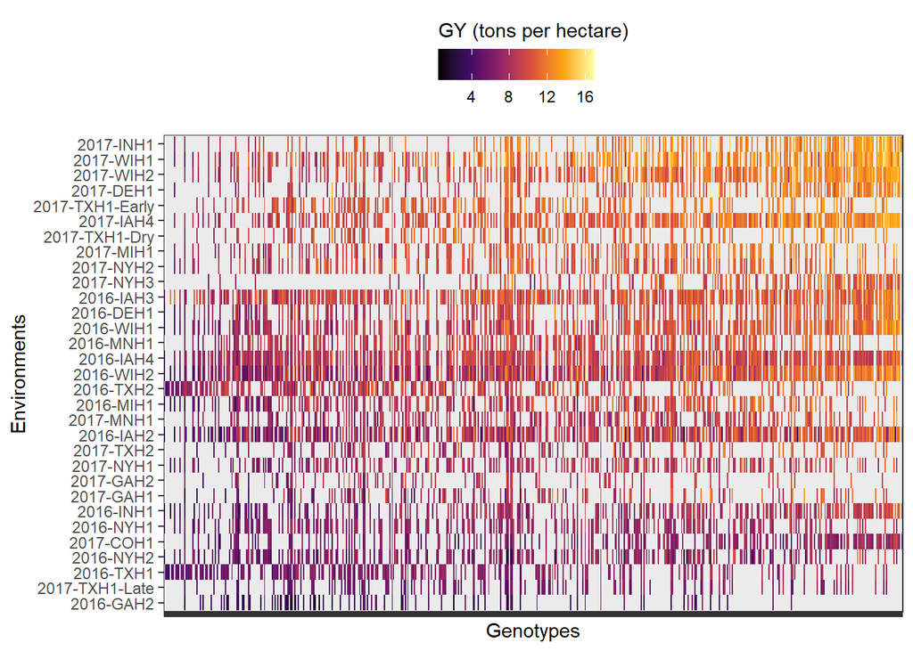

Figure 3: BLUEs of grain yield (filled cells) of each genotype (x-axis) per environment (y-axis). Both genotypes and environments are in sorted in decreasing order. The blank cells are environments in which the genotype was not evaluated

```r
blues |> ggplot(aes(x = reorder(genotype, blue), y = reorder(env, blue), fill = blue)) +
  geom_tile() + theme_bw() +
  theme(legend.position = 'top',
        axis.text.x = element_blank(), legend.title.position = 'top') +
  scale_fill_viridis_c(option = 'inferno') +
  labs(x = "Genotypes", y = "Environments", fill = "GY (tons per hectare)")
```

Figure 4 depicts the experimental precison of each environment (a visualization also used in Chaves et al., 2024). The ideal is that trials have a low CV and a high $H^2$ (which will depend on the assessed trait, population, etc.). For instance, 2017-TXH1-Early is the most precise trial. 2017-ILH1 had a nil broad-sense heritability. Indeed, when we check Figure 5, this environment had $\sigma^2_g = 0$. This explains why the P-value of the LRT indicates the non-rejection of the null hyphotesis.

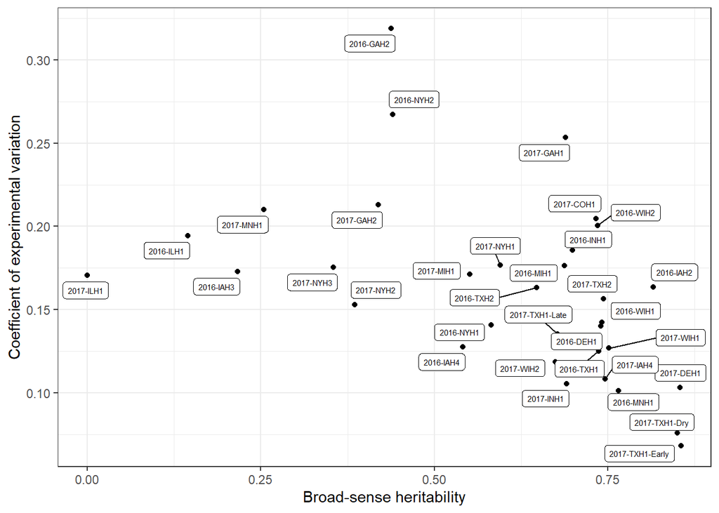

Figure 4: Broad-sense heritability (x-axis) and coefficient of experimental variation (in decimal scale, y-axis) of the tested environments

```r
params |> ggplot(aes(x = H2, y = CV)) +
  geom_point() +
  geom_label_repel(aes(label = env), size = 2) +
  theme_bw() +
  labs(x = "Broad-sense heritability", y = "Coefficient of experimental variation")
```

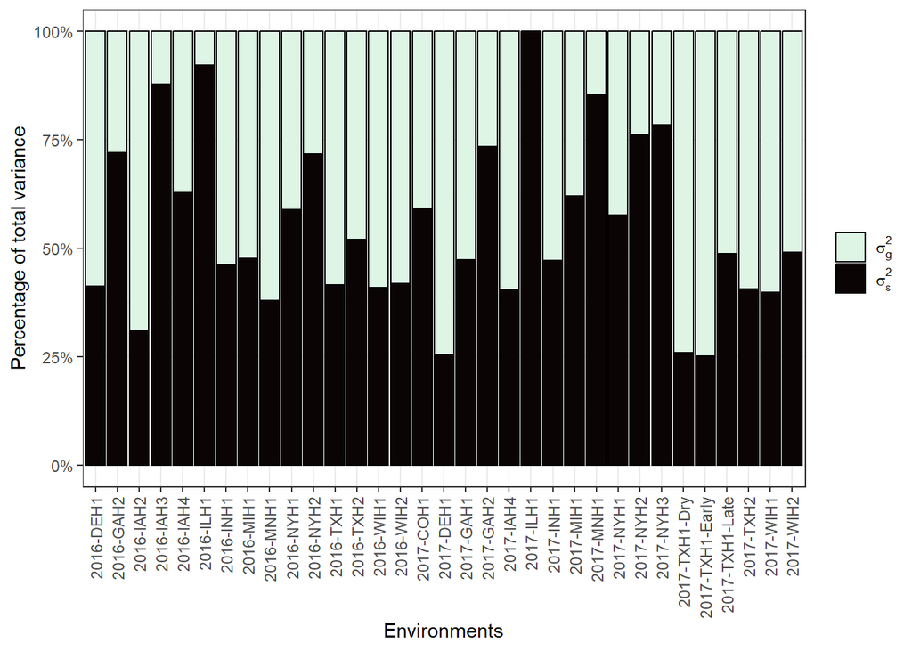

Figure 5: Ratio of genotypic (blue) and residual (black) variances to the total variance, per environment (x-axis)

```r
data.frame(
  env = params$env,
  s2g = apply(params[,2:3], 1, function(x) x[1]/(x[1] + x[2])),
  s2e = apply(params[,2:3], 1, function(x) x[2]/(x[1] + x[2]))
) |>
  pivot_longer(s2g:s2e) |>
  ggplot(aes(x = env, y = value, fill = factor(name, levels = c("s2g", 's2e')))) +
  geom_col(color = 'black') + theme_bw() +
  theme(legend.position = 'right',
        axis.text.x = element_text(angle = 90, vjust = 0.5, hjust = 1)) +
  labs(x = "Environments", y = "Percentage of total variance", fill = '') +
  scale_y_continuous(labels = scales::percent) +
  scale_fill_viridis_d(option = 'mako', direction = -1,
                       labels = c('s2g' = expression(sigma[g]^2),
                                  's2e' = expression(sigma[epsilon]^2)))
```

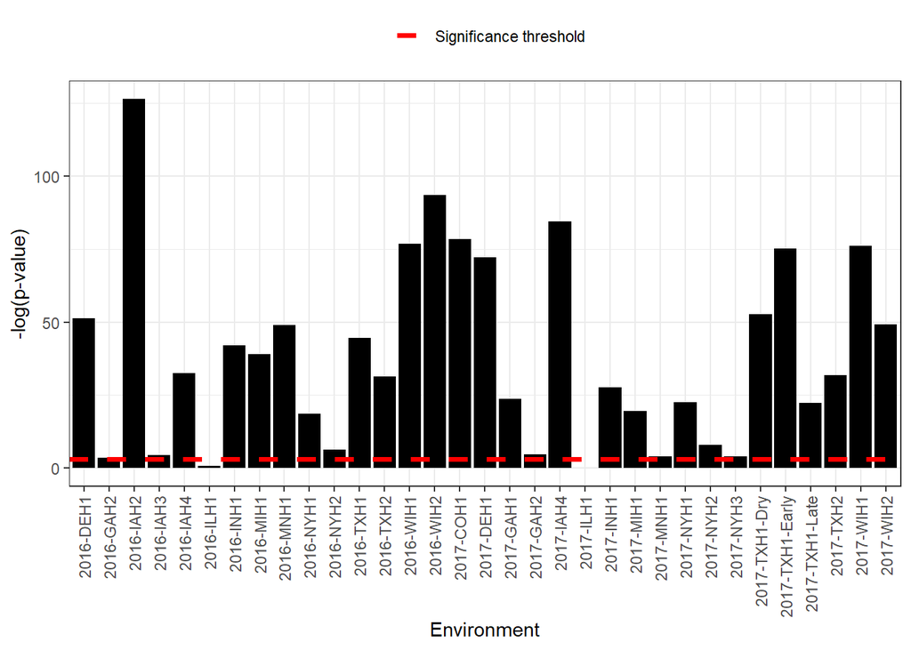

Figure 6: P-values (y-axis) of the likelihood ratio test. The horizontal dashed line depicts the significance threshold (0.05): environments with -log(p-value) lower than the threshold indicate non-significance)

```r
params |> ggplot(aes(x = env, y = -log(lrt))) +
  theme_bw() +
  theme(axis.text.x = element_text(angle = 90, vjust = .5, hjust = 1), legend.position = 'top') +
  geom_col(fill = 'black') +
  geom_hline(aes(yintercept = -log(0.05), linetype = "Significance threshold"),
             colour = "red", linewidth = 1.4) +
  scale_linetype_manual(values = 'dashed') +
  labs(x = "Environment", y = "-log(p-value)", linetype = '')
```

**Note**

Environments where the genotypic effects were non-significant (2016-ILH1 and 2017-ILH1) were discarded in the first stage.

# 4 Molecular data

$$\mathbf{G} = \frac{\mathbf{M}^\prime \mathbf{M}}{p}$$

where $\mathbf{M}$ is the scaled and centered SNP matrix, and $p$ is the number of columns of $\mathbf{M}$, i.e., the number of SNPs.

```r
geno = as.data.frame(data.table::fread(file = 'data/GENO.csv'))
rownames(geno) = NULL; rownames(geno) = geno[,1]; geno = geno[,-1]; geno = as.matrix(geno)
geno = geno[which(rownames(geno) %in% unique(blues$genotype)),]
dim(geno)
matnames = dimnames(geno)
geno[1:5,1:5]

# MAF
freq <- apply(geno, 2, function(x) {
  mean(x, na.rm = TRUE)
})/2
MAF <- apply(rbind(freq, 1 - freq), 2, min)

geno = geno[,-which(MAF < 0.05)]
dim(geno)
G = tcrossprod(apply(geno, 2, scale))/ncol(geno)
rownames(G) = colnames(G) = rownames(geno$M.clean)
```

The code above takes time, so let’s just load the GRM:

```r
Gmat = readRDS(file = "Gmat.rds")
dim(Gmat)
```

```
[1] 567 567
```

Using the GRM, we can visualize the relationship between hybrids using a principal component analysis (PCA, Figure 7).

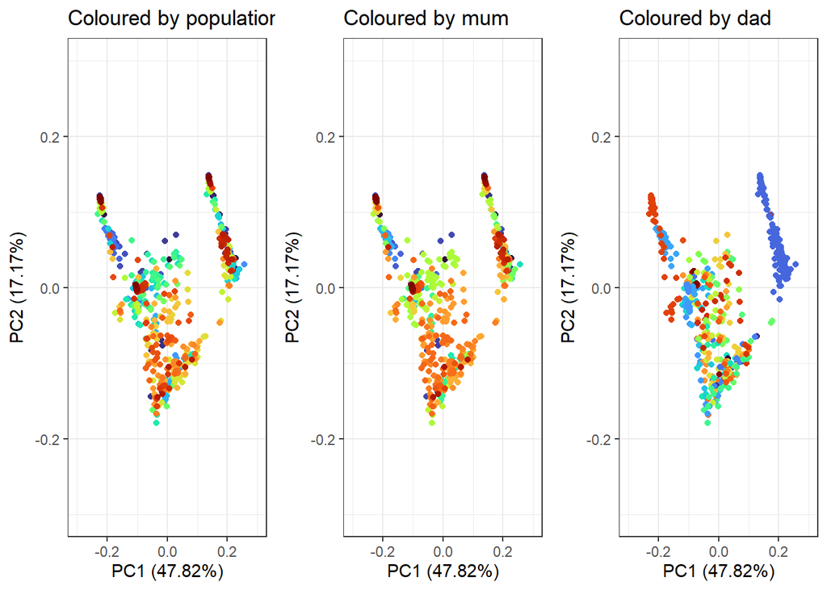

Figure 7: Principal component analysis plot built from the genomic relationship matrix. The three plots show the same PCA, coloured using different criteria

```r
pca = FactoMineR::PCA(X = Gmat, scale.unit = FALSE, graph = FALSE)

par = do.call(rbind, str_split(rownames(pca$var$coord), '/'))
pc.df = data.frame(
  geno = rownames(pca$var$coord),
  p1 = par[,1], p2 = par[,2],
  pc1 = pca$var$coord[,1],
  pc2 = pca$var$coord[,2], row.names = NULL
)

ggarrange(
  pc.df |> ggplot(aes(x = pc1, y = pc2)) +
    geom_point(aes(colour = geno)) +
    theme_bw() +
    theme(legend.position = 'none') +
    labs(x = paste0("PC1 (", round(pca$eig[1,2], 2),"%)"),
         y = paste0("PC2 (", round(pca$eig[2,2], 2),"%)"),
         title = "Coloured by population")+
    ylim(-0.3, 0.3) + xlim(-.3, .3)+
    scale_colour_viridis_d(option = 'turbo'),

  pc.df |> ggplot(aes(x = pc1, y = pc2)) +
    geom_point(aes(colour = p1)) +
    theme_bw() +
    theme(legend.position = 'none') +
    labs(x = paste0("PC1 (", round(pca$eig[1,2], 2),"%)"),
         y = paste0("PC2 (", round(pca$eig[2,2], 2),"%)"),
         title = "Coloured by mum")+
    ylim(-0.3, 0.3) + xlim(-.3, .3)+
    scale_colour_viridis_d(option = 'turbo'),

  pc.df |> ggplot(aes(x = pc1, y = pc2)) +
    geom_point(aes(colour = p2)) +
    theme_bw() +
    theme(legend.position = 'none') +
    labs(x = paste0("PC1 (", round(pca$eig[1,2], 2),"%)"),
         y = paste0("PC2 (", round(pca$eig[2,2], 2),"%)"),
         title = "Coloured by dad") +
    ylim(-0.3, 0.3) + xlim(-.3, .3) +
    scale_colour_viridis_d(option = 'turbo'),
  nrow = 1
)
```

# 5 Environmental data

Now let’s handle the environmental data:

```r
envcov = read.csv(file = 'data/ECOV.csv')
colnames(envcov)[1] = "env"
```

There are 202 environmental features. These features are divided according to maize’s physiological phases: germination, emergence, juvenile phase, floral initiation, flag leaf emergence, flowering, grain filling, maturity and harvesting. For more details, check the file “ECOV_period”.

The first step is to remove the environments discarded due to non-significance of genotypic effects from the `envcov` object:

```r
envcov = envcov[which(envcov$env %in% blues$env),]
```

Now, we build $\mathbf{W}$, the scaled and centred matrix of enviromental features. With it, we build $\mathbf{\Omega}$, the environmental kernel (or a kind of “environmental relationship matrix”):

$$\mathbf{\Omega} = \frac{\mathbf{W}^\prime \mathbf{W}}{q}$$

with $q$ being the number of columns of $\mathbf{W}$.

```r
rownames(envcov) = envcov[,1]; envcov = envcov[,-1]
W = scale(envcov, center = TRUE, scale = TRUE)
Omega = tcrossprod(W)/ncol(W)
dim(Omega)
```

```
[1] 31 31
```

# 6 Second-stage analysis

The second-stage analysis are done using the BLUEs from the fist stage. But before delving into the analyses, there are some preparations we have to do first.

## 6.1 Design matrices

In the second stage, we will use the `BGLR` package. To use it, we have to build the covariance matrices and construct the linear predictor. But first, let’s build the design matrices for our two effects: environment (say, $\mathbf{Z}_1$) and hybrids (let’s call it $\mathbf{Z}_2$).

```r
Zenv = model.matrix(~-1 + env, data = blues)
colnames(Zenv) = gsub("env", "", colnames(Zenv))
Zhyb = model.matrix(~-1 + genotype, data = blues)
colnames(Zhyb) = gsub("genotype", "", colnames(Zhyb))

rownames(Zenv) = rownames(Zhyb) = blues$genotype
```

## 6.2 Covariance matrices

According to Jarquin et al. (2014), an effective way of considering the interaction between molecular markers and environmental features is by using a multiplicative model, essentially like:

$$y_i = \mu + w_i + g_i + gw_i + \varepsilon_i$$

The covariance structure of $gw_i$ is $\mathbf{gw} \sim \mathcal{N}(\mathbf{0}, \mathbf{G} \# \mathbf{\Omega})$, with $\#$ representing the Hadamard (point-by-point) product. In most cases, $\mathbf{G}$ and $\mathbf{\Omega}$ are non-compatible, This is why we build the design matrices first. By doing matrix operations between the genomic and environmental kernels and the design matrices, we make all matrices readily compatible. Another important detail that you will note in the code below is that we build the covariance functions of both the genotype-by-environmental features (G$\omega$I) interaction and the genotype-by-environment interaction. Both interactions will be used in our model. The idea is that the missing environmental factors that could not be accounted by G$\omega$I are captured by the GEI component.

```r
ZGZ_hyb = tcrossprod(tcrossprod(Zhyb, Gmat), Zhyb)
ZOZ_env = tcrossprod(tcrossprod(Zenv, Omega), Zenv)
ZZ_env = tcrossprod(Zenv)
GEIO_H = ZGZ_hyb * ZOZ_env
GEI_H = ZGZ_hyb * ZZ_env
```

This leads to the following model:

$$\mathbf{\overline{y}} = \mathbf{1}\mu + \mathbf{Z}_1 \mathbf{e} + \mathbf{Z}_2 \mathbf{g} + \mathbf{Z}_3 \mathbf{ge} + \mathbf{Z}_4 \mathbf{g \boldsymbol{\omega}} + \boldsymbol{\varepsilon}$$

with $\mathbf{e} \stackrel{i.i.d.}{\sim} NMV(\mathbf{0}, \sigma^2_e \mathbf{I})$, $\mathbf{g} \stackrel{i.i.d.}{\sim} NMV(\mathbf{0}, \sigma^2_g \mathbf{G})$, $\mathbf{ge} \stackrel{i.i.d.}{\sim} NMV[\mathbf{0}, \sigma^2_{ge} (\mathbf{Z}_2 \mathbf{G}_A \mathbf{Z}_2' \# \mathbf{Z}_1 \mathbf{Z}_1')]$, and $\mathbf{g\boldsymbol{\omega}} \stackrel{i.i.d.}{\sim} NMV[\mathbf{0}, \sigma^2_{g\omega} (\mathbf{Z}_2 \mathbf{G} \mathbf{Z}_2' \# \mathbf{Z}_1 \mathbf{\Omega} \mathbf{Z}_1')]$.

## 6.3 Genomic prediction

To fit models in `BGLR`, we must first build the `ETA` object. Here, we define the model for each effect. This model refers to how the package will deal with a given effect. The RKHS (acronym for Reproducing Kernel Hilbert Space) is an equivalent to the GBLUP.

```r
ETA = list(
  env = list(V = eigen(ZZ_env)$vectors, d = eigen(ZZ_env)$values, model = 'RKHS'),
  hyb = list(V = eigen(ZGZ_hyb)$vectors, d = eigen(ZGZ_hyb)$values, model = 'RKHS'),
  gei = list(V = eigen(GEI_H)$vectors, d = eigen(GEI_H)$values, model = 'RKHS'),
  gwi = list(V = eigen(GEIO_H)$vectors, d = eigen(GEIO_H)$values, model = 'RKHS')
)
```

### 6.3.1 Leave-one-out cross-validation

Let’s check how well the model predicts untested environments. This is done using a leave-one-environment-out cross-validation procedure. To show how this validation is data-dependent, we will use two environments as examples:

- Environment “2016-DEH1”

```r
yNA = blues$blue
yNA[which(blues$env == '2016-DEH1')] = NA

cvmod = BGLR::BGLR(y = yNA, ETA = ETA, nIter = 12000, burnIn = 2000)
unlink("*.dat")

predvals = cbind(
  blues[which(blues$env == '2016-DEH1'),c('hybrid','env','blue')],
  yhat = cvmod$yHat[which(blues$env == '2016-DEH1')]
)
```

```r
load(file = "predvals_DEH1.RDA")
cor(predvals$blue, predvals$yhat)
```

```
[1] 0.742526
```

```r
mean(predvals$yhat - predvals$blue)^2
```

```
[1] 2.190748
```

- Environment “2017-NYH3”

```r
yNA = blues$blue
yNA[which(blues$env == '2017-NYH3')] = NA

cvmod = BGLR::BGLR(y = yNA, ETA = ETA, nIter = 12000, burnIn = 2000)
unlink("*.dat")

predvals = cbind(
  blues[which(blues$env == '2017-NYH3'),c('hybrid','env','blue')],
  yhat = cvmod$yHat[which(blues$env == '2017-NYH3')]
)
```

```r
load(file = "predvals_NYH3.RDA")
cor(predvals$blue, predvals$yhat)
```

```
[1] 0.4114012
```

```r
mean(predvals$yhat - predvals$blue)^2
```

```
[1] 0.9656543
```

## 7 References

Araújo, M. S., Chaves, S. F. S., Dias, L. A. S., Ferreira, F. M., Pereira, G. R., Bezerra, A. R. G., Alves, R. S., Heinemann, A. B., Breseghello, F., Carneiro, P. C. S., Krause, M. D., Costa-Neto, G., & Dias, K. O. G. (2024). GIS-FA: An approach to integrating thematic maps, factor-analytic, and envirotyping for cultivar targeting. *Theoretical and Applied Genetics*, *137*(4), 80. https://doi.org/10.1007/s00122-024-04579-z

Campos, G. de los, Pérez-Rodríguez, P., Bogard, M., Gouache, D., & Crossa, J. (2020). A data-driven simulation platform to predict cultivars’ performances under uncertain weather conditions. *Nature Communications*, *11*(1), 4876. https://doi.org/10.1038/s41467-020-18480-y

Chaves, S. F. S., Damacena, M. B., Dias, K. O. G., Oliveira, C. V. A., & Bhering, L. L. (2024). Factor analytic selection tools and environmental feature-integration enable holistic decision-making in *eucalyptus* breeding. *Scientific Reports*, *14*(1), 18429. https://doi.org/10.1038/s41598-024-69299-2

Costa-Neto, G., Fritsche-Neto, R., & Crossa, J. (2021). Nonlinear kernels, dominance, and envirotyping data increase the accuracy of genome-based prediction in multi-environment trials. *Heredity*, *126*(1), 92–106. https://doi.org/10.1038/s41437-020-00353-1

Fernandes, I. K., Vieira, C. C., Dias, K. O. G., & Fernandes, S. B. (2024). Using machine learning to combine genetic and environmental data for maize grain yield predictions across multi-environment trials. *Theoretical and Applied Genetics*, *137*(8), 189. https://doi.org/10.1007/s00122-024-04687-w

Jarquin, D., Crossa, J., Lacaze, X., Du Cheyron, P., Daucourt, J., Lorgeou, J., Piraux, F., Guerreiro, L., Pérez, P., Calus, M., Burgueño, J., & Campos, G. de los. (2014). A reaction norm model for genomic selection using high-dimensional genomic and environmental data. *Theoretical and Applied Genetics*, *127*(3), 595–607. https://doi.org/10.1007/s00122-013-2243-1

Resende, R. T., Xavier, A., Silva, P. I. T., Resende, M. P. M., Jarquin, D., & Marcatti, G. E. (2024). GIS-based G × E modeling of maize hybrids through enviromic markers engineering. *New Phytologist*, *n/a*(n/a). https://doi.org/10.1111/nph.19951

Toda, Y., Sasaki, G., Ohmori, Y., Yamasaki, Y., Takahashi, H., Takanashi, H., Tsuda, M., Kajiya-Kanegae, H., Tsujimoto, H., Kaga, A., Hirai, M., Nakazono, M., Fujiwara, T., & Iwata, H. (2024). Reaction norm for genomic prediction of plant growth: Modeling drought stress response in soybean. *Theoretical and Applied Genetics*, *137*(4), 77. https://doi.org/10.1007/s00122-024-04565-5